# Explanations with 2 causes

Erin Bennett

Speaker and listener *and literal* (i.e. make sure listener knows that speaker knows that listener knows…) have in common ground:

- ☑ prob_of_causal_link
- ☑ parent_prior_prob
- ☑ causal_strength
- ☑ effect_background_prior_prob
- ☑ causal_structure_prior
- ☑ actual states of A, B, and E

Some of those should be marginalized:

- ☐ prob_of_causal_link
- ☑ parent_prior_prob
- ☑ causal_strength
- ☑ effect_background_prior_prob

We’ll marginalize these whenever we have uncertainty about the existence of causal links, i.e. whenver we `forward_sample`.

Speaker knows:

- ☑ causal_structure.AE
- ☑ causal_structure.BE

## Interpretation Model:

Given “E because A,” estimate causal_structure.AE and causal_structure.BE.

## Speaker Model:

Given causal_structure.AE and causal_structure.BE, endorse “E because A,” relative to a set of alternative explanations we offer (pick one).

## Inferrable parameters:

- ☐ stickiness parameter
- ☐ speaker rationality (at level ☐ s1 and at level ☐ s2)

## Fixed parameters:

- lexical presuppositions/entailments (but this is OK if common ground is fixed)
- QUD is cause, because that’s the only unknown for the listener
- alternative utterances / alternative explanations:
  - “E because A”
  - “E because B”
  - “null”
  - (each of these is equally probable)

## Model predictions with inferrable parameters fixed

First, get model predictions with all of the inferrable parameters fixed.

Fixed values:

- ☑ `prob_of_causal_link = 0.5`
- ☑ `parent_prior_prob = 0.5`
- ☑ `causal_strength = 0.9`
- ☑ `effect_background_prior_prob = 0`
- ☑ `stickiness parameter = 0.53` (L&K’s fit value)
- ☑ `speaker rationality = 1` (at level ☑ s1 and at level ☑ s2)

As stated above, the QUD is fixed to be only the causal links, the background knowledge is that all variables (A, B, and E) are true, and alternative utterances are as stated above.

Speaker’s (S1) descriptions:

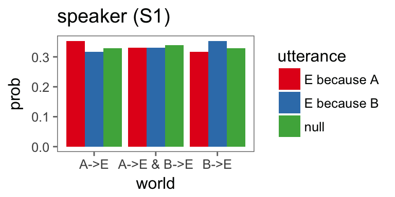

Listener’s interpretations:

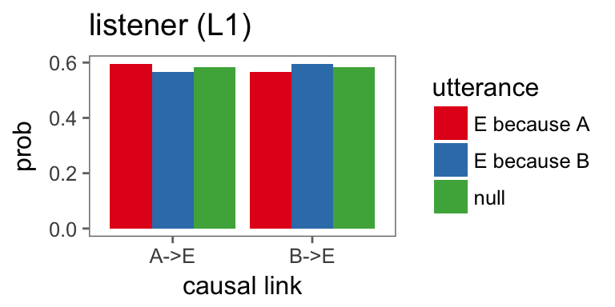

Here’s what happens when we marginalize S1 over `causal_strength`, `parent_prior_prob`, and `effect_background_prior_prob` (with a uniform prior). It’s very similar. **this takes 4 minutes to run**

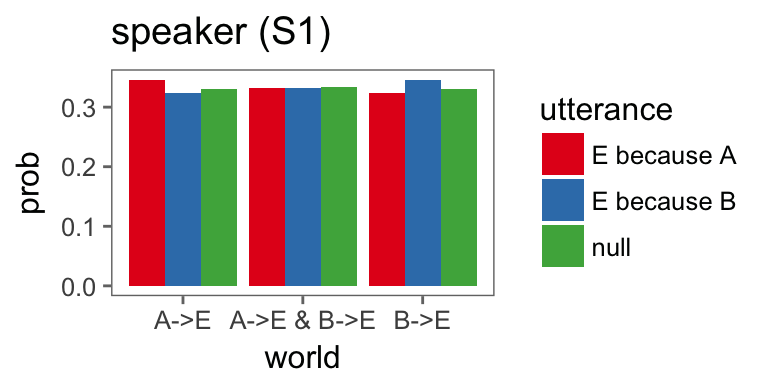